# Graphical Analysis

## 5.4 Violin plots (supplementary, optional sub-section)

Violin plots combine ideas from both density plots and box plots. They show density distributions and can incorporate other elements, like strip charts.

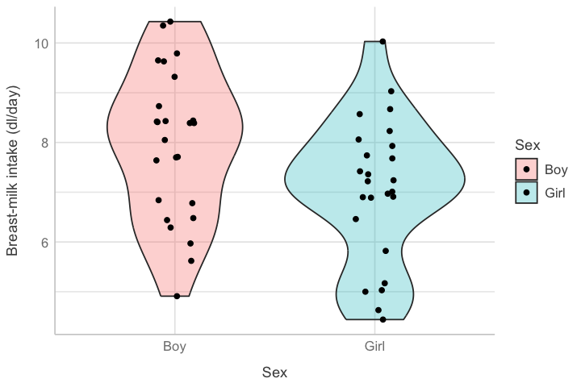

Figure 33: Comparison of breast-milk intake distributions by sex.

```r
kfm |>
  gf_violin(dl.milk ~ sex, fill = ~ sex, alpha = 0.3) |>
  gf_jitter(dl.milk ~ sex, width = 0.1, height = 0)
```

For larger datasets, we can add summary of statistics using error bars indicating the mean and 95% CI around mean values.

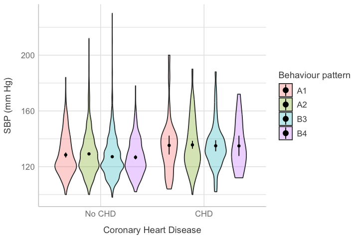

Figure 34: Comparison of systolic blood pressure (SBP) by coronary heart disease event, stratified by behaviour pattern.

```r
wcgs |>
  gf_violin(sbp ~ chd, fill = ~ beh_pat, alpha = 0.3) |>
  gf_summary(
    fun.data = "mean_cl_boot",
    geom = "pointrange", fatten = 1,
    position = position_dodge(width = 0.9)
  )
```

## 5.5 Bar charts

Bar charts or bar plots are used, most of the time, to display information from a table graphically. Therefore, for publications are not the best option as a table uses less space and contains better information.

For example, we can use `gf_counts` from the `ggformula` package to graphically compare the frequency distributions of babies with low birth weights by race.

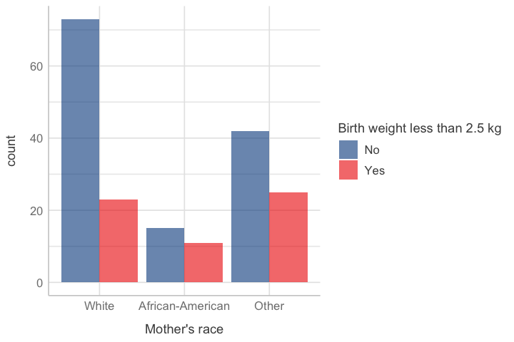

Figure 35: Distribution of lower birth weights by race.

```r
birthwt |>
  gf_counts(~ race, fill = ~ low, position = "dodge", alpha = 0.6) |>
  gf_refine(ggsci::scale_fill_lancet())
```

We had already shown the use of box plots. In box plots, we are comparing medians and distributions instead of means. It is because of that limitation that some authors favour the use of bar charts in which the height of the bars represent mean values for each group and error bars are included to show dispersion. For *inferential statistics* we would show either standard errors or 95% CIs.

In the `pubh` package there is a function that automatically does that.

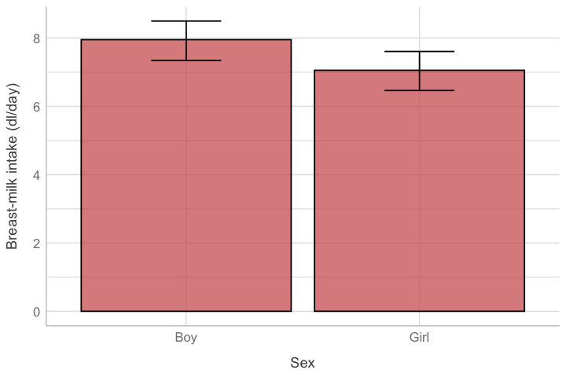

Figure 36: Comparison of breast-milk intake between boys and girls. Bar heights are mean values and error bars represent 95% CIs (bootstrap).

```r
kfm |>
  bar_error(dl.milk ~ sex)
```

As it was the case with strip plots, we can also construct bar plots stratified by a second factor:

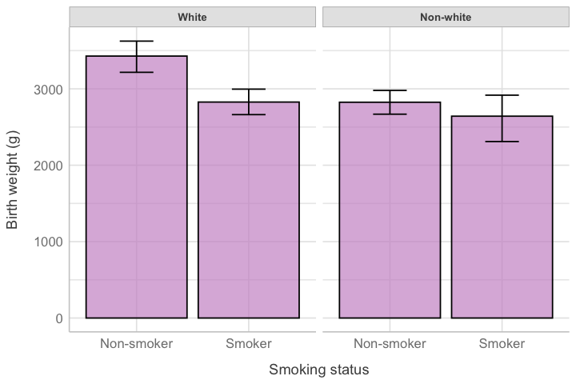

Figure 37: Comparison of birth weights of babies born from mothers with different smoking status, stratified by race. Height of bars represent mean birth weight values for each group and error bars, 95% CI around those mean values.

```r
birthwt |>
  bar_error(bwt ~ smoke|Race, fill = 'plum3')
```

It is also possible to play with `col` and `fill` and to add more layers, like `gf_star`.

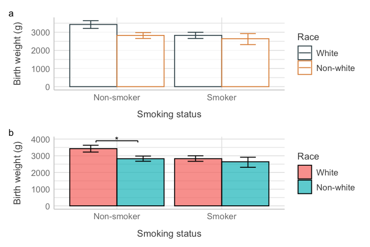

Figure 38: Comparison of birth weights of babies born from mothers with different smoking status, stratified by race. Height of bars represent mean birth weight values for each group and error bars, 95% CI around those mean values. (a) Example showing the effect of col by group. (b) Example showing the effect of fill by group ($^*p$ < 0.05).

```r
p1 = birthwt |>
  bar_error(
    bwt ~ smoke, col = ~ Race,
    fill = "white"
  ) |>
  gf_refine(jama) |>
  axis_labs()

p2 = birthwt |>
  bar_error(bwt ~ smoke, fill = ~ Race) |>
  axis_labs() |>
  gf_refine(jama) |>
  gf_star(x1 = 0.8, x2 = 1.2, y1 = 3800, y2 = 3900, y3 = 3950)

plots(p1, p2, n_rows = 2, tags = "a")
```

# 6 Exporting figures

When you are working in your `RMarkdown` documents, there is no need to export figures, and everything is done automatically.

When you run your commands interactively, plots are shown in the *Plots* tab. The easiest way to export them is to click on `Export` and select `Save as PDF`. PDF figures can be inserted in Word, Power Point, Keynote, Pages, etc. The plot will be saved as shown on your viewer, not always the best idea. Word and Power Point work better with `.png` figures.

## 6.1 Postscript figures

We have more control if we export the file using the function `pdf` than exporting them with the viewer. When we use this option, the instruction could be part of our script file. We need three sections of code to export a figure this way:

1. The first section creates the file and defines the size of the plot. The units are in inches.
2. The second section makes the plot.
3. The third section is used to close the device. Is a way to tell the system that we have finished the plot.

```r
pdf("figures/fig6.pdf", height = 4, width = 5.3, pointsize = 9)
birthwt |>
  gf_density(~ bwt | smoke, fill = ~ race, alpha = 0.3)
dev.off()
```

For publications, is more common that publishers will ask for a `.eps` file (encapsulated postscript). The command is very similar.

```r
postscript("figures/fig15.eps", height = 4, width = 5.3,
           pointsize = 9, horizontal = FALSE)
kfm |>
  gf_point(dl.milk ~ mat.weight, pch = ~ sex, col = ~ sex) |>
  gf_lm(col = ~ sex) |>
  gf_refine(jama)
dev.off()
```